# Project 7: Difference-in-Differences and Synthetic Control

```r
# Install and load packages
if (!require("pacman")) install.packages("pacman")
devtools::install_github("ebenmichael/augsynth")
```

```r
pacman::p_load(# Tidyverse packages including dplyr and ggplot2
               tidyverse,
               ggthemes,
               augsynth,
               gsynth)
library(dplyr)
library(tidyr)
library(ggplot2)
library(scales)
# set seed
set.seed(44)

# load data
medicaid_expansion <- read_csv("data/medicaid_expansion.csv")
colnames(medicaid_expansion)
```

```
## [1] "State"          "Date_Adopted"   "year"           "uninsured_rate"
## [5] "population"
```

# Introduction

For this project, you will explore the question of whether the Affordable Care Act increased health insurance coverage (or conversely, decreased the number of people who are uninsured). The ACA was passed in March 2010, but several of its provisions were phased in over a few years. The ACA instituted the “individual mandate” which required that all Americans must carry health insurance, or else suffer a tax penalty. There are four mechanisms for how the ACA aims to reduce the uninsured population:

- Require companies with more than 50 employees to provide health insurance.
- Build state-run healthcare markets (“exchanges”) for individuals to purchase health insurance.
- Provide subsidies to middle income individuals and families who do not qualify for employer based coverage.
- Expand Medicaid to require that states grant eligibility to all citizens and legal residents earning up to 138% of the federal poverty line. The federal government would initially pay 100% of the costs of this expansion, and over a period of 5 years the burden would shift so the federal government would pay 90% and the states would pay 10%.

In 2012, the Supreme Court heard the landmark case NFIB v. Sebelius, which principally challenged the constitutionality of the law under the theory that Congress could not institute an individual mandate. The Supreme Court ultimately upheld the individual mandate under Congress’s taxation power, but struck down the requirement that states must expand Medicaid as impermissible subordination of the states to the federal government. Subsequently, several states refused to expand Medicaid when the program began on January 1, 2014. This refusal created the “Medicaid coverage gap” where there are indivudals who earn too much to qualify for Medicaid under the old standards, but too little to qualify for the ACA subsidies targeted at middle-income individuals.

States that refused to expand Medicaid principally cited the cost as the primary factor. Critics pointed out however, that the decision not to expand primarily broke down along partisan lines. In the years since the initial expansion, several states have opted into the program, either because of a change in the governing party, or because voters directly approved expansion via a ballot initiative.

You will explore the question of whether Medicaid expansion reduced the uninsured population in the U.S. in the 7 years since it went into effect. To address this question, you will use difference-in-differences estimation, and synthetic control.

# Data

The dataset you will work with has been assembled from a few different sources about Medicaid. The key variables are:

- **State**: Full name of state
- **Medicaid Expansion Adoption**: Date that the state adopted the Medicaid expansion, if it did so.
- **Year**: Year of observation.
- **Uninsured rate**: State uninsured rate in that year.

# Exploratory Data Analysis

Create plots and provide 1-2 sentence analyses to answer the following questions:

- Which states had the highest uninsured rates prior to 2014? The lowest?
- Which states were home to most uninsured Americans prior to 2014? How about in the last year in the data set? **Note**: 2010 state population is provided as a variable to answer this question. In an actual study you would likely use population estimates over time, but to simplify you can assume these numbers stay about the same.

```r
# Highest and lowest uninsured rates
#Find years in dataset
unique(medicaid_expansion$year)
```

```
##  [1] 2008 2009 2010 2011 2012 2013 2014 2015 2016 2017 2018 2019 2020
```

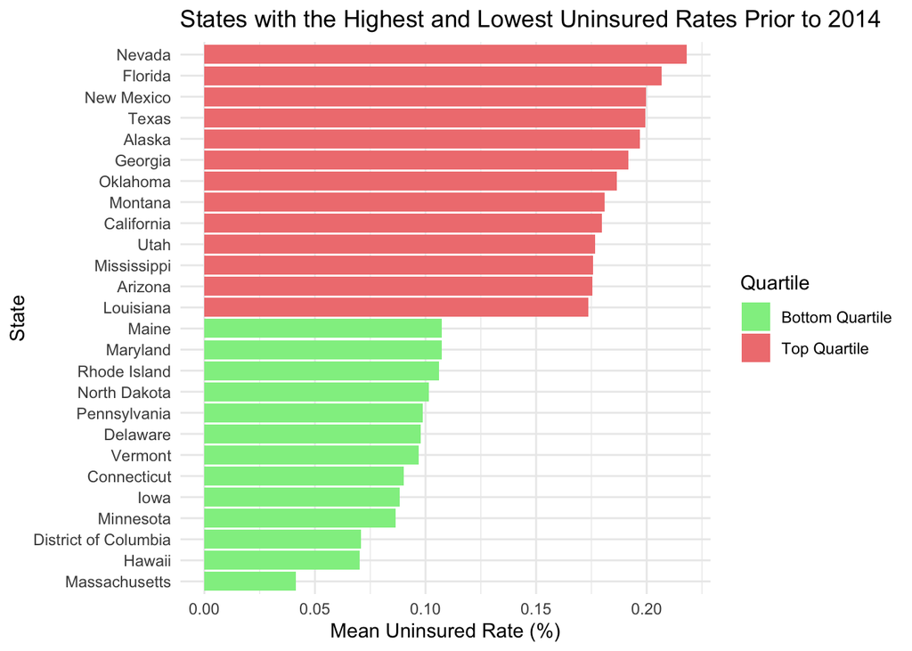

```r
# Filter data for all years prior to 2014
pre2014_data <- medicaid_expansion %>%
  filter(year < 2014)

# Uninsured rates prior to 2014 (Going to take the mean of all years prior, not taking it year by year, will update if this is a mistake)
pre2014_uninsuredrate <- pre2014_data %>%
  group_by(State) %>%
  summarize(mean_uninsured_rate = mean(uninsured_rate)) %>%
  arrange(desc(mean_uninsured_rate)) %>%
  mutate(State = factor(State, levels = State))

#Find top and bottom quartiles (calling this the highest and lowest, since I don't want to plot all 50 states)
# Calculate the 25th and 75th percentiles (Quartiles)
q1 <- quantile(pre2014_uninsuredrate$mean_uninsured_rate, 0.25)
q3 <- quantile(pre2014_uninsuredrate$mean_uninsured_rate, 0.75)

# Filter states in the bottom and top quartiles based on mean uninsured rate
bottom_quartile2014 <- pre2014_uninsuredrate %>%
  filter(mean_uninsured_rate <= q1) %>%
  mutate(Quartile = 'Bottom Quartile')

top_quartile2014 <- pre2014_uninsuredrate %>%
  filter(mean_uninsured_rate >= q3) %>%
  mutate(Quartile = 'Top Quartile')

# Combine both quartiles into a single data frame
combined_quartiles <- bind_rows(bottom_quartile2014, top_quartile2014)

# Create a plot for both top and bottom quartiles
ggplot(combined_quartiles, aes(x = reorder(State, mean_uninsured_rate), y = mean_uninsured_rate, fill = Quartile)) +
  geom_bar(stat = 'identity') +
  coord_flip() +
  labs(title = 'States with the Highest and Lowest Uninsured Rates Prior to 2014',
       x = 'State',
       y = 'Mean Uninsured Rate (%)') +
  scale_fill_manual(values = c('Bottom Quartile' = 'lightgreen', 'Top Quartile' = 'lightcoral')) +
  theme_minimal()
```

I decided to plot uninsured population rates pre-2014 as an average of those rates over the pre-2014 years in the study period (2008-2013). I understand that I lose some naunce here because rates could be way higher/lower at some point in this pre-2014 period leading to a deceiving average, whereas looking at this yearly would allow me to see those trends over time pre-2014, but for the sake of exploratory analyses, I like this visual. I will return to this if it seems like later on I should be looking year to year. It looks like the states with the lowest rates of uninsured individuals pre-2014 are mostly northern/midwestern states, and the highest rates of uninsured individuals are southern/western states. P.S., it’s noted that D.C. is missing population data. If that becomes an issue, I’ll take it out of the dataset.

```r
library(dplyr)
# most uninsured Americans
# Calculate total uninsured population for each state prior to 2014
pre2014_uninsuredrate <- pre2014_data %>%
  group_by(State) %>%
  summarize(
    mean_uninsured_rate = mean(uninsured_rate),
    population = first(population)  #Since there's only one unique value for each state (because it's based on 2010 population), just choosing the first
  ) %>%
  mutate(
    total_uninsured_population = population * mean_uninsured_rate
  ) %>%
  arrange(desc(total_uninsured_population)) %>%
  mutate(State = factor(State, levels = State))

#Caluclate total uninsured population for each state in 2020
uninsured_2020 <- medicaid_expansion %>%
  filter(year == 2020) %>%
  group_by(State) %>%
  summarize(
    uninsured_rate_2020 = first(uninsured_rate),  # Use the uninsured rate directly for 2020
    population = first(population)  # Use the population for the state
  ) %>%
  mutate(
    total_uninsured_population_2020 = population * uninsured_rate_2020
  ) %>%
  arrange(desc(total_uninsured_population_2020))
glimpse(pre2014_uninsuredrate)
```

```
## Rows: 51
## Columns: 4
## $ State                      <fct> California, Texas, Florida, New York, Georg…
## $ mean_uninsured_rate        <dbl> 0.1796478, 0.1992837, 0.2068583, 0.1145605,…
## $ population                 <dbl> 38802500, 26956958, 19893297, 19746227, 100…
## $ total_uninsured_population <dbl> 6970785.1, 5372081.4, 4115094.3, 2262137.6,…
```

```r
glimpse(uninsured_2020)
```

```
## Rows: 51
## Columns: 4
## $ State                           <chr> "Texas", "California", "Florida", "Geo…
## $ uninsured_rate_2020             <dbl> 0.184, 0.077, 0.132, 0.134, 0.113, 0.0…
## $ population                      <dbl> 26956958, 38802500, 19893297, 10097343…
## $ total_uninsured_population_2020 <dbl> 4960080.3, 2987792.5, 2625915.2, 13530…
```

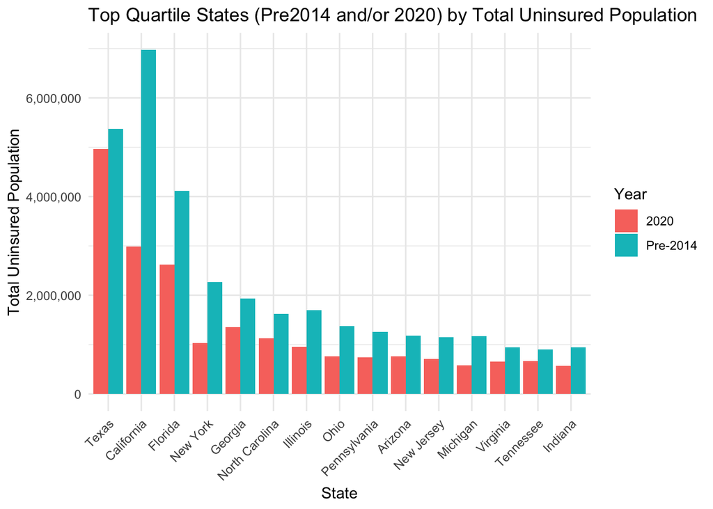

```r
# Filter states in the top quartiles pre-2014 and in 2020 based on total uninsured population rates
library(ggplot2)
library(scales)  # for comma format
library (tidyr)
#Define cutoffs
q3_2014 <- quantile(pre2014_uninsuredrate$total_uninsured_population, 0.75, na.rm = TRUE)
q3_2020 <- quantile(uninsured_2020$total_uninsured_population_2020, 0.75, na.rm = TRUE)

#Filter states in the top quartile for both time periods
pre2014_top <- pre2014_uninsuredrate %>%
  mutate(Year = "Pre-2014") %>%
  mutate(in_top_quartile_2014 = total_uninsured_population >= q3_2014) %>%
  select(State, total_uninsured_population_2014 = total_uninsured_population, in_top_quartile_2014)

post2020_top <- uninsured_2020 %>%
  mutate(Year = "2020") %>%
  mutate(in_top_quartile_2020 = total_uninsured_population_2020 >= q3_2020) %>%
  select(State, total_uninsured_population_2020, in_top_quartile_2020)

# Full join on State to preserve all states that were in either top quartile
combined_all_states <- full_join(pre2014_top, post2020_top, by = "State")

# Filter out states that weren't in the top quartile for either time period
combined_all_states <- combined_all_states %>%
  filter(in_top_quartile_2014 == TRUE | in_top_quartile_2020 == TRUE)

# Reformat data for plotting
plot_data <- combined_all_states %>%
  pivot_longer(cols = starts_with("total_uninsured_population"),
               names_to = "Year",
               values_to = "total_uninsured_population") %>%
  mutate(Year = recode(Year,
                       "total_uninsured_population_2014" = "Pre-2014",
                       "total_uninsured_population_2020" = "2020"))

# Create a plot for both top quartiles, adding the data for a state if it was in the top quartile for either time period
ggplot(plot_data, aes(x = reorder(State, -total_uninsured_population, na.rm = TRUE),
                      y = total_uninsured_population,
                      fill = Year)) +
  geom_bar(stat = "identity", position = "dodge", na.rm = TRUE) +
  labs(title = "Top Quartile States (Pre2014 and/or 2020) by Total Uninsured Population",
       x = "State",
       y = "Total Uninsured Population") +
  scale_y_continuous(labels = scales::comma) +
  theme_minimal() +
  theme(axis.text.x = element_text(angle = 45, hjust = 1))
```

It looks like the total population of uninsured people went down from pre-2014 levels for all states in 2020. California seems to have a huge difference, Florida and New York too, and then Texas looks like it didn’t change that much. It’s important to note that the graph includes states that were in the top quartile of total uninsured individuals for either pre-2014 or in 2020, so some of these states might not have been in the top quartile for both time periods.

# Difference-in-Differences Estimation

## Estimate Model

Do the following:

- Choose a state that adopted the Medicaid expansion on January 1, 2014 and a state that did not. **Hint**: Do not pick Massachusetts as it passed a universal healthcare law in 2006, and also avoid picking a state that adopted the Medicaid expansion between 2014 and 2015.
- Assess the parallel trends assumption for your choices using a plot. If you are not satisfied that the assumption has been met, pick another state and try again (but detail the states you tried).

```r
#Find out when states adopted medicaid expansion, create a column indicating whether or not state ever adopted
medicaid_adoption <- medicaid_expansion %>%
  distinct(State, Date_Adopted) %>%
  mutate(
    Adopted = ifelse(is.na(Date_Adopted), "Never Expanded", "Expanded")
  ) %>%
  arrange(Date_Adopted)

#Merge with dataset
medicaid_expansion$Date_Adopted <- as.Date(medicaid_expansion$Date_Adopted)
medicaid_adoption$Date_Adopted <- as.Date(medicaid_adoption$Date_Adopted)
medicaid_expansion_full <- medicaid_expansion %>%
  left_join(medicaid_adoption %>% select(State, Date_Adopted, Adopted), by = "State") %>%
  select(-Date_Adopted.x) %>%
  rename(Date_Adopted = Date_Adopted.y)
colnames(medicaid_expansion_full)
```

```
## [1] "State"          "year"           "uninsured_rate" "population"
## [5] "Date_Adopted"   "Adopted"
```

```r
#When it says "choose a state that did not" I'm assuming this means choose a state that never adopted the expansion, not a state that adopted the expansion just not between 2014-205 (e.g. 2020)
#Find states that adopted expansion on 1/1/2014 and those who didn't at all, create a new dataframe to work on
compare_states <- medicaid_expansion_full %>%
  filter(Date_Adopted == as.Date("2014-01-01") | Adopted == "Never Expanded")
compare_states <- compare_states %>%
  left_join(pre2014_uninsuredrate %>%
              select(State, total_uninsured_population, mean_uninsured_rate),
            by = "State")
```

I had such a hard time trying to figure out how to show parallel trends lol. As I’ve griped about in class, I feel like parallel trends are pretty unconvincing, it’s pretty easy for me to think something fails the eye test unless the lines are, like, really similar.

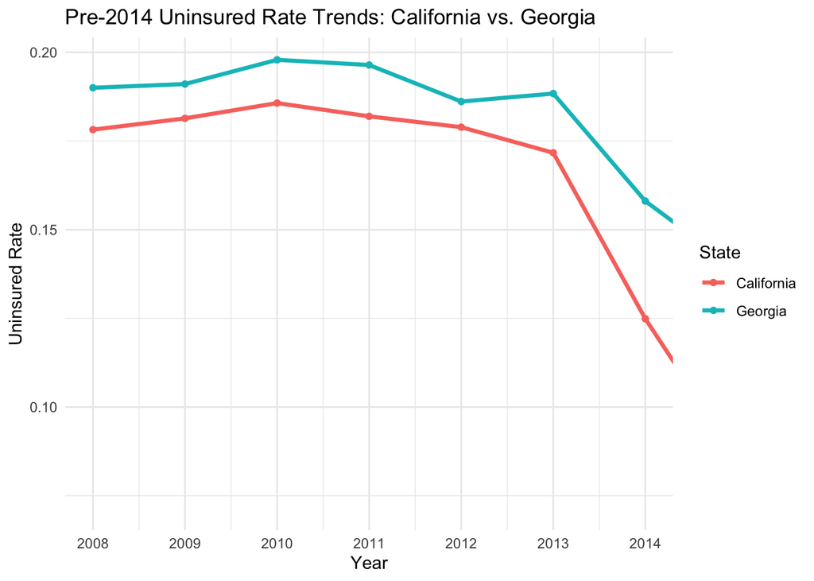

```r
#Parallel trends plot
parallel_data <- compare_states %>%
  filter(State %in% c("California", "Georgia")) %>%
  select(State, year, uninsured_rate)

parallel_data <- parallel_data %>%
  mutate(year = as.integer(year))

ggplot(parallel_data, aes(x = year, y = uninsured_rate, color = State)) +
  geom_line(size = 1.2) +
  geom_point() +
  scale_x_continuous(breaks = seq(min(parallel_data$year), 2014, 1),
                     labels = as.character(seq(min(parallel_data$year), 2014, 1))) +
  coord_cartesian(xlim = c(min(parallel_data$year), 2014)) +  # truncate the plot at 2014
  labs(title = "Pre-2014 Uninsured Rate Trends: California vs. Georgia",
       x = "Year",
       y = "Uninsured Rate",
       color = "State") +
  theme_minimal()
```

```r
#Find two states, one that never adopted the expansion and one that adopted 1/1/2014 that are similar in terms of uninsured_rates, populations, and total_uninsured populations prior to 2014
compare_states %>%
  filter(State %in% c("California", "Georgia")) %>%
  distinct(State, population, Date_Adopted, mean_uninsured_rate, total_uninsured_population) %>%
  print()
```

```
## # A tibble: 2 × 5
##   State      population Date_Adopted mean_uninsured_rate total_uninsured_popul…¹
##   <chr>           <dbl> <date>                     <dbl>                   <dbl>
## 1 California   38802500 2014-01-01                 0.180                6970785.
## 2 Georgia      10097343 NA                         0.192                1935272.
## # ℹ abbreviated name: ¹total_uninsured_population
```

This was the best I could do… the parallel trends look visually the best out of any pair I tested (I spent like an hour and a half trying), but I know obviously that there are reasons to believe that Georgia and California are very different. That being said, when weighing the visual parallel trends vs. our real world knowledge of these policy contexts, which is important? For example, I kept trying jurisdictions that seemed similar enough (Kentucky vs. Alabama) but their parallel trends visually just couldn’t be justified to me. Not sure if this was the better move or if I should’ve picked a “worse” trend visually that made more sense in the real world.

- Estimates a difference-in-differences estimate of the effect of the Medicaid expansion on the uninsured share of the population. You may follow the lab example where we estimate the differences in one pre-treatment and one post-treatment period, or take an average of the pre-treatment and post-treatment outcomes

```r
# Difference-in-Differences estimation
#Create dataframe
cg <- compare_states %>%
  filter(State %in% c("California", "Georgia")) %>%
  filter(year %in% c(2013, 2014))

#Pre-treatment difference
pre_diff <- cg %>%
  filter(year == 2013) %>%
  select(State, uninsured_rate) %>%
  pivot_wider(names_from = State, values_from = uninsured_rate) %>%
  summarise(diff = California - Georgia)
#post-treatment diference
post_diff <- cg %>%
  filter(year == 2014) %>%
  select(State, uninsured_rate) %>%
  pivot_wider(names_from = State, values_from = uninsured_rate) %>%
  summarise(diff = California - Georgia)

#DiD
diff_in_diffs <- post_diff - pre_diff
diff_in_diffs
```

```
##       diff
## 1 -0.01648
```

## Discussion Questions

# Synthetic Control

Estimate Synthetic Control

Although several states did not expand Medicaid on January 1, 2014, many did later on. In some cases, a Democratic governor was elected and pushed for a state budget that included the Medicaid expansion, whereas in others voters approved expansion via a ballot initiative. The 2018 election was a watershed moment where several Republican-leaning states elected Democratic governors and approved Medicaid expansion. In cases with a ballot initiative, the state legislature and governor still must implement the results via legislation. For instance, Idaho voters approved a Medicaid expansion in the 2018 election, but it was not implemented in the state budget until late 2019, with enrollment beginning in 2020.

Do the following:

- Choose a state that adopted the Medicaid expansion after January 1, 2014. Construct a non-augmented synthetic control and plot the results (both pre-treatment fit and post-treatment differences). Also report the average ATT and L2 imbalance.

```r
# non-augmented synthetic control
#Find delayed adopters
adopted_post2014 <- medicaid_expansion_full %>%
  filter(Date_Adopted > as.Date("2014-12-31")) %>%
  distinct(State, Date_Adopted)

view(adopted_post2014)
#I'm not sure if I should be using some theory-informed state for the synthetic control, but my gut is telling me to pick a state that adopted on New Years day of some year. Earlier in the notebook it said don't choose 2014 or 2015 for DiD, so I won't choose either. Therefore, I'll choose 01-01-2016 as my date, which hopefully will still give me enough data post-treatment.
treated_state <- "Montana"
treatment_year <- medicaid_expansion_full %>%
  filter(State == treated_state) %>%
  pull(Date_Adopted) %>%
  unique() %>%
  as.Date() %>%
  format("%Y") %>%
  as.numeric()
# Clean data
medicaid_clean <- medicaid_expansion_full %>%
  mutate(
    treatment = ifelse(State == treated_state & year >= treatment_year, 1, 0)
  )

# Run non-augmented synthetic control
syn <- augsynth(
  uninsured_rate ~ treatment,  # Outcome variable and treatment indicator
  unit = State,                # Unit (states)
  time = year,                 # Time variable (year)
  data = medicaid_clean,       # Data frame
  progfunc = "none",           # No augmentation
  scm = TRUE                   # Enable synthetic control
)
```

```
## One outcome and one treatment time found. Running single_augsynth.
```

```r
#Save ATT and L2 imbalance
# Extract the ATT and L2 Imbalance from the summary text (I was having issues with getting the ATT out of the summary)
summary_text <- capture.output(summary(syn))
att_line <- summary_text[grep("Average ATT Estimate", summary_text)]
l2_line <- summary_text[grep("L2 Imbalance", summary_text)]

# Extract the numeric values for ATT and L2 Imbalance
non_aug_att <- as.numeric(str_extract(att_line, "[-]?\\d+\\.\\d+"))
non_aug_l2 <- as.numeric(str_extract(l2_line, "[-]?\\d+\\.\\d+"))

# Print out the results
cat("Non-Augmented ATT:", non_aug_att, "\n")
```

```
## Non-Augmented ATT: -0.0189
```

```r
cat("Non-Augmented L2 Imbalance:", non_aug_l2, "\n")
```

```
## Non-Augmented L2 Imbalance: 0.009
```

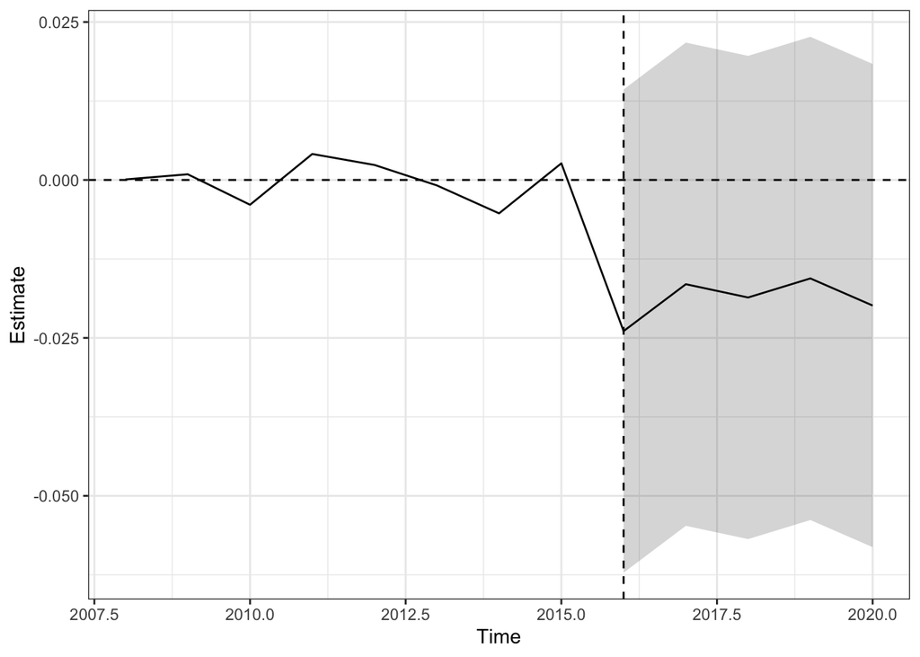

```r
# plot
plot(syn)
```

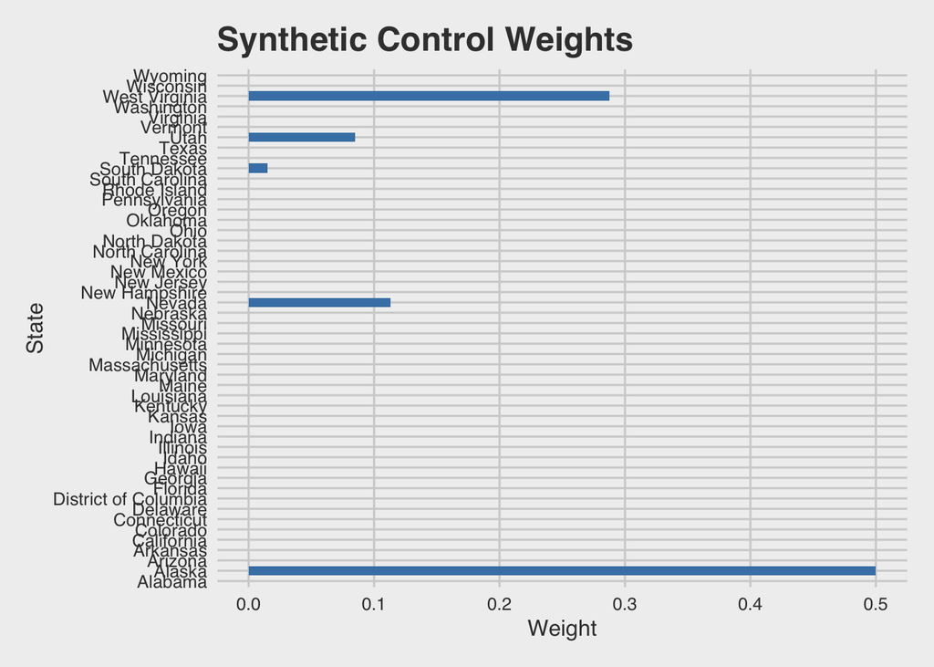

```r
weights_df <- data.frame(syn$weights) %>%
  tibble::rownames_to_column('State') %>%
  rename(syn_weight = syn.weights)

# Plot weights
library(ggplot2)
library(ggthemes)

ggplot(weights_df) +
  geom_col(aes(x = State, y = syn_weight), fill = "steelblue") +
  coord_flip() +
  theme_fivethirtyeight() +
  theme(axis.title = element_text()) +
  labs(
    title = "Synthetic Control Weights",
    x = "State",
    y = "Weight"
  )
```

Okay, only a few states are donors (is that the right terminology?) for our synthetic control.

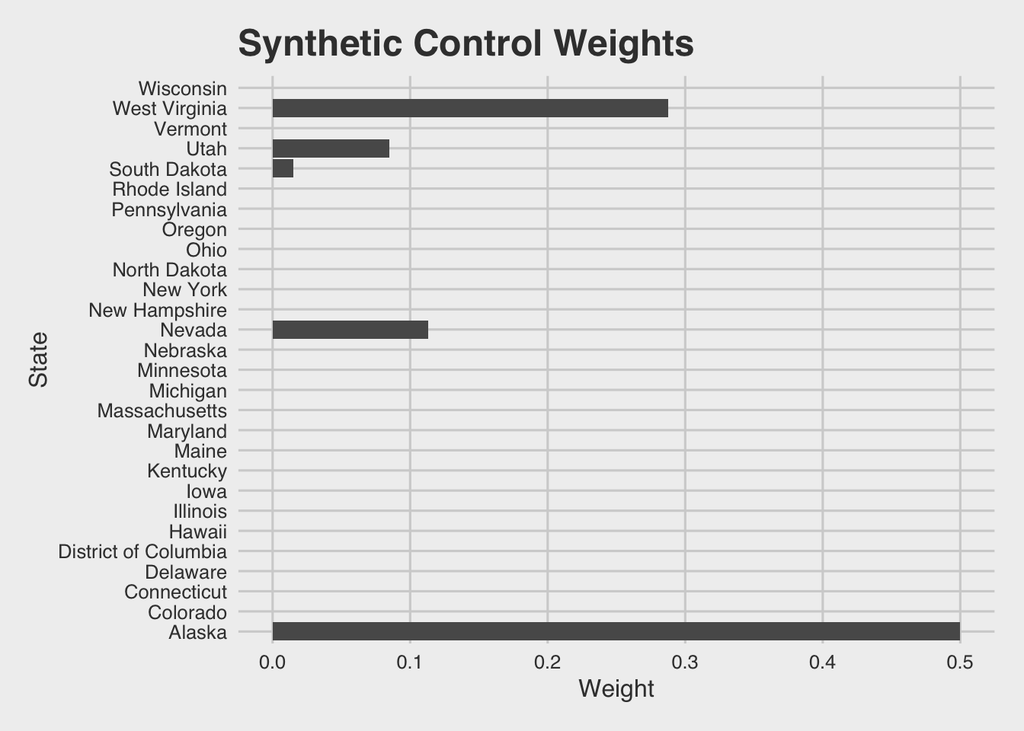

```r
# view each state's contribution, where weights are greater than 0
# ---------
data.frame(syn$weights) %>%
  # processing
  # ---------
  tibble::rownames_to_column('State') %>%
  filter(syn.weights > 0) %>% # filter out weights less than 0
  # plot
  # ---------
  ggplot() +
  geom_bar(aes(x = State,
               y = syn.weights),
           stat = 'identity') +
  coord_flip() +   # flip to make it more readable
  # themes
  theme_fivethirtyeight() +
  theme(axis.title = element_text()) +
  # labels
  ggtitle('Synthetic Control Weights') +
  xlab('State') +
  ylab('Weight')
```

```r
#Use tidysynth to visualize
library(tidysynth)

medicaid_out <- medicaid_clean %>%
  synthetic_control(
    outcome = uninsured_rate,
    unit = State,
    time = year,
    i_unit = "Montana",      # Treated unit
    i_time = 2016,           # Intervention time
    generate_placebos = TRUE
  ) %>%
  # Use a different approach to generate predictors
  generate_predictor(
    time_window = 2008:2013,
    avg_uninsured = mean(uninsured_rate, na.rm = TRUE)  # Use a summary statistic instead
  ) %>%
  generate_weights(optimization_window = 2008:2015) %>%
  generate_control()
```

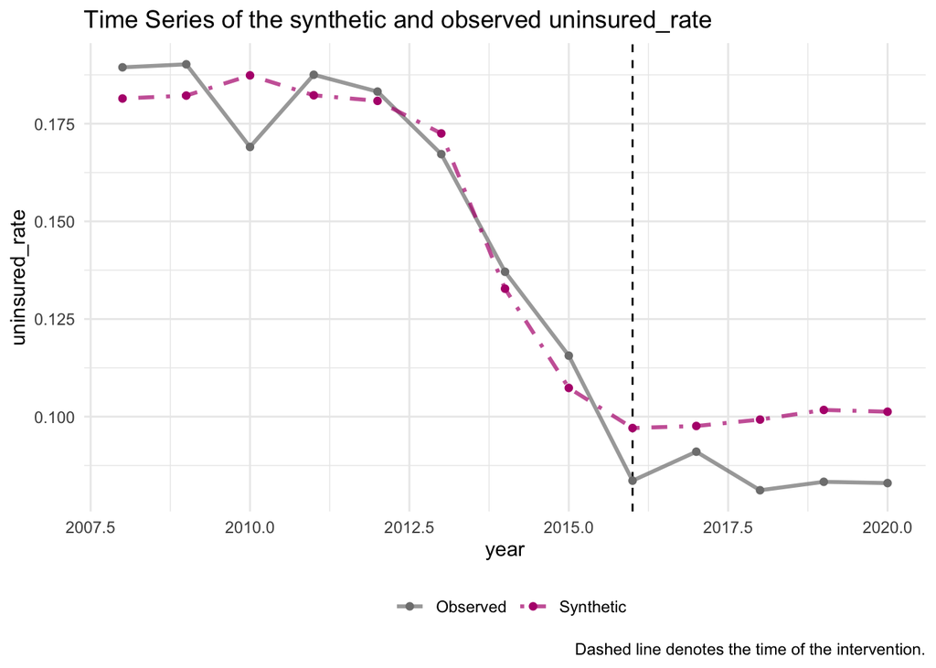

```r
#Plot trends for Montana vs synthetic Montana
medicaid_out %>% plot_trends()
```

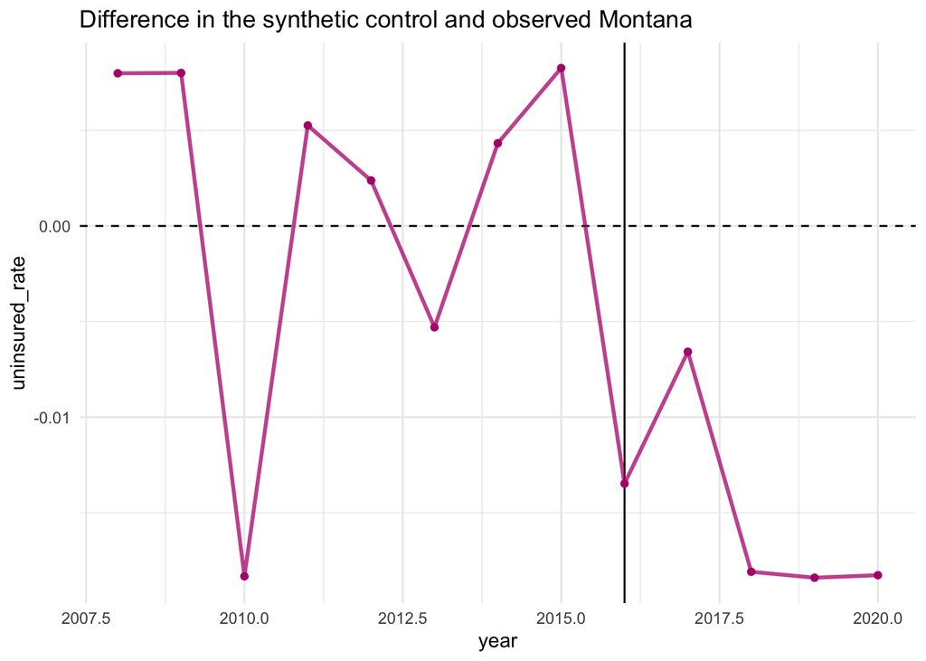

```r
#Plot the differences (gap between actual and synthetic Montana)
medicaid_out %>% plot_differences()
```

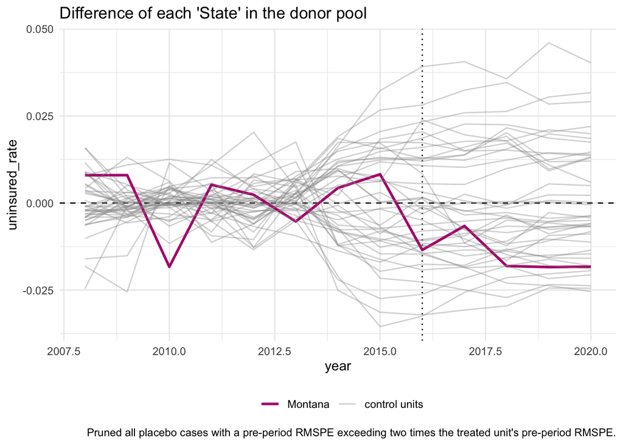

```r
#Plot placebos (other donor states) vs observed Montana
medicaid_out %>% plot_placebos()
```

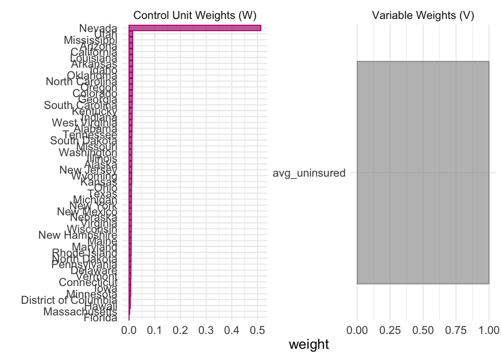

```r
#Plot control weights of each other state
medicaid_out %>% plot_weights()
```

…uhhh why is Nevada the only donor state basically… also why is it the avg_unisnured

- Re-run the same analysis but this time use an augmentation (default choices are Ridge, Matrix Completion, and GSynth). Create the same plot and report the average ATT and L2 imbalance.

```r
# augmented synthetic control
aug_syn <- augsynth(
  uninsured_rate ~ treatment,
  unit = State,
  time = year,
  data = medicaid_clean,
  progfunc = "ridge", # Using ridge regression for augmentation
  scm = TRUE
)
```

```
## One outcome and one treatment time found. Running single_augsynth.
```

```r
# Extract the ATT and L2 Imbalance using the same approach as before (same issue getting ATT)
summary_aug_text <- capture.output(summary(aug_syn))
aug_att_line <- summary_aug_text[grep("Average ATT Estimate", summary_aug_text)]
aug_l2_line <- summary_aug_text[grep("L2 Imbalance", summary_aug_text)]

# Extract the numeric values
aug_att <- as.numeric(str_extract(aug_att_line, "[-]?\\d+\\.\\d+"))
aug_l2 <- as.numeric(str_extract(aug_l2_line, "[-]?\\d+\\.\\d+"))

# Print out the results
cat("Augmented ATT:", aug_att, "\n")
```

```
## Augmented ATT: -0.0189
```

```r
cat("Augmented L2 Imbalance:", aug_l2, "\n")
```

```
## Augmented L2 Imbalance: 0.009
```

```r
cat("Non-Augmented L2 Imbalance (for comparison):", non_aug_l2, "\n")
```

```
## Non-Augmented L2 Imbalance (for comparison): 0.009
```

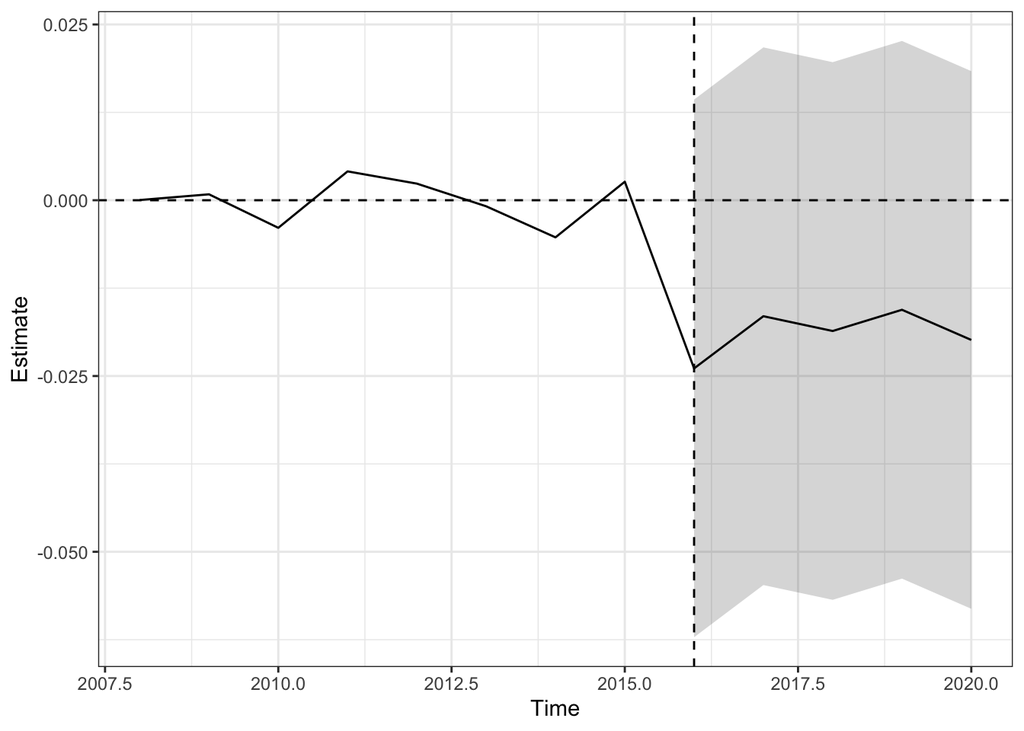

```r
plot(aug_syn)
```

- Plot barplots to visualize the weights of the donors.

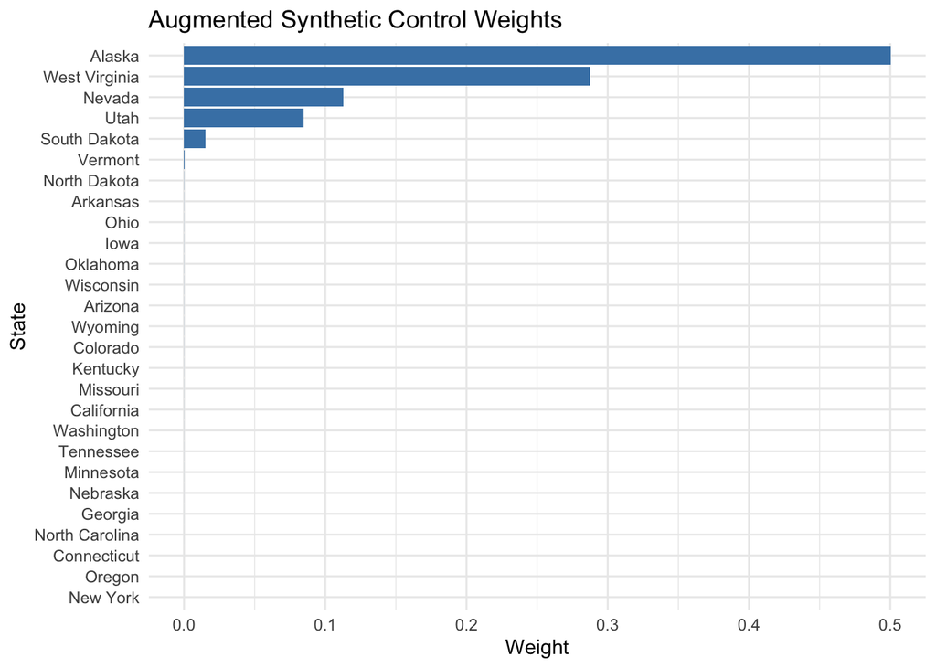

```r
# barplots of weights
weights_plot <- data.frame(aug_syn$weights) %>%
  tibble::rownames_to_column('State') %>%
  filter(aug_syn.weights > 0) %>%
  ggplot() +
  geom_bar(aes(x = reorder(State, aug_syn.weights), y = aug_syn.weights),
           stat = 'identity', fill = "steelblue") +
  coord_flip() +
  theme_minimal() +
  labs(
    title = "Augmented Synthetic Control Weights",
    x = "State",
    y = "Weight"
  )

print(weights_plot)
```

…why are none of the weights negative

```r
# # Create a comparison plot between actual, non-aug synthetic, and ridge Montana
# # Aniket's method for getting the underlying data
# syn_sum <- summary(syn)
#
# # create synthetic Kansas
# # ---------
# montana_synmontana <-
#   # data
#   medicaid_expansion_full %>%
#   # filter just Kansas
#   filter(state == "Montana") %>%
#   # bind columns
#   bind_cols(difference = syn_sum$att$Estimate) %>%    # add in estimate
#   # calculate synthetic Kansas
#   mutate(synthetic_montana = lngdpcapita + difference) # adds the estimate to the observed Kansas to create synthetic Kansas
#
# ridge_sum <- summary(ridge_syn)
#
# # create synthetic Kansas
# # ---------
# kansas_synkansas_ridgesynkansas <- kansas_synkansas %>%
#   bind_cols(ridge_difference = ridge_sum$att$Estimate) %>%
#   mutate(ridge_synthetic_kansas = lngdpcapita + ridge_difference)
#
# # plot
# # ---------
# kansas_synkansas_ridgesynkansas %>%
#   ggplot() +
#
#   # kansas
#   # ---------
#   geom_line(aes(x = year_qtr,
#                 y = lngdpcapita,
#                 color = 'Kansas')) +
#   # synthetic kansas
#   # ---------
#   geom_line(aes(x = year_qtr,
#                 y = synthetic_kansas,
#                 color = 'Synthetic Kansas')) +
#   # ridge kansas
#   # ---------
#   geom_line(aes(x = year_qtr,
#                 y = ridge_synthetic_kansas,
#                 color = 'Ridge Synthetic Kansas')) +
#   # use scale color manual to assign color values
#   scale_color_manual(values = c('Kansas' = 'red',
#                                 'Synthetic Kansas' = 'blue',
#                                 'Ridge Synthetic Kansas' = 'green')) +
#   geom_vline(aes(xintercept = 2012.5)) +
#   # themes
#   theme_fivethirtyeight() +
#   theme(axis.title = element_text()) +
#   # labels
#   ggtitle('Kansas, Synthetic Kansas, Ridge Synthetic Kansas') +
#   xlab('Year-Quarter') +
#   ylab('State GDP Per Capita')
```

Fix this code to include synthetic montana based on the example notebook on kansas that did the manual calculations **HINT**: Is there any preprocessing you need to do before you allow the program to automatically find weights for donor states?

## Discussion Questions

# Staggered Adoption Synthetic Control

## Estimate Multisynth

Do the following:

- Estimate a multisynth model that treats each state individually. Choose a fraction of states that you can fit on a plot and examine their treatment effects.

```r
# multisynth model states
```

[output not shown]

- Estimate a multisynth model using time cohorts. For the purpose of this exercise, you can simplify the treatment time so that states that adopted Medicaid expansion within the same year (i.e. all states that adopted epxansion in 2016) count for the same cohort. Plot the treatment effects for these time cohorts.

```r
# multisynth model time cohorts
```

[output not shown]

## Discussion Questions

# General Discussion Questions